# ADA2: Class 21, Ch 13, Principal Components Analysis (PCA)

Tim Farkas

April 11, 2022

# 1 NM County-level Poverty Data

In this example we’ll use NM county-level poverty data to understand how counties differ by living conditions, and how those living conditions vary together. We hope to reduce our 13-dimensional dataset to the vital few components that explain about 75% of the variability.

**Maps:** *Labels are easier to read on the left, but road features on right make the counties easier to place.*

[figure not shown]

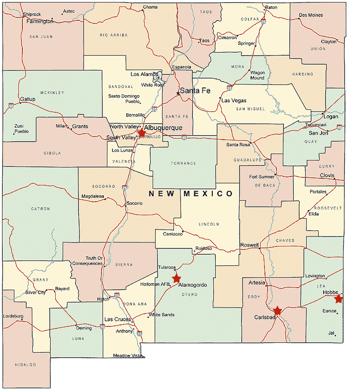

Here is a description of the codebook for this data.

```
NM county-level poverty data from S16 student:
Nathan Dobie, Student Technical Specialist, Bureau of Business Economic Research, UNM
Thanks, Nathan!

Data combined from:
http://bber.unm.edu/county-profiles                                        (poverty)
http://factfinder.census.gov/bkmk/table/1.0/en/ACS/14_5YR/DP04/0400000US35 (other values)
http://www2.census.gov/geo/docs/reference/codes/files/national_county.txt  (county names)

DATA COLUMNS:
 1 area
 2 county
 3 periodyear (2014)
   -Vacancy Status %
 4   Homeowner vacancy rate
 5   Rental vacancy rate
   -Occupancy Status %
 6   Owner-occupied
 7   Renter-occupied
   -Main source of heating (% of homes)
 8   Utility gas
 9   Electricity
10   Wood
11 Lacking complete plumbing facilities %
12 No telephone service available %
13 rentover35        (gross rent as a percentage of household income (grapi))
   -Poverty
14   est_percent     (Estimated percent of people of all ages in poverty)
15   child_percent   (Estimate of people age 0-17 in poverty)
16   fam_percent     (Estimated percent of related children age 5-17 in families in poverty)
```

```r
library(tidyverse)

# First, download the data to your computer,
#   save in the same folder as this Rmd file.

# read the data
dat_nmcensus <-
  read_csv(
    "ADA2_CL_21_PCA_NMCensusPovertyHousingCharacteristics_DP04.csv"
  , skip = 1
  ) %>%
  rename(
    # Shorter column names
    "Area"     = "area"
  , "County"   = "county"
  , "Year"     = "periodyear"
  , "VacantH"  = "Homeowner vacancy rate"
  , "VacantR"  = "Rental vacancy rate"
  , "Owner"    = "Owner-occupied"
  , "Renter"   = "Renter-occupied"
  , "HeatG"    = "Utility gas"
  , "HeatE"    = "Electricity"
  , "HeatW"    = "Wood"
  , "NoPlumb"  = "Lacking complete plumbing facilities"
  , "NoPhone"  = "No telephone service available"
  , "Rent35"   = "rentover35"
  , "PovAll"   = "est_percent"
  , "PovChild" = "child_percent"
  , "PovFam"   = "fam_percent"
  ) %>%
  filter(
    # remove state average, use county-level
    Area != 0
  )

# remove column attributes from read_csv()
attr(dat_nmcensus, "spec") <- NULL

# columns to use for analysis,
use_col_ind <- c(4:6, 8:14)
use_col_names <- names(dat_nmcensus)[use_col_ind]
use_col_names
```

```
 [1] "VacantH" "VacantR" "Owner"   "HeatG"   "HeatE"   "HeatW"   "NoPlumb"
 [8] "NoPhone" "Rent35"  "PovAll"
```

```r
str(dat_nmcensus)
```

```
spec_tbl_df [33 × 16] (S3: spec_tbl_df/tbl_df/tbl/data.frame)
 $ Area    : num [1:33] 1 3 5 6 7 9 11 13 15 17 ...
 $ County  : chr [1:33] "Bernalillo" "Catron" "Chaves" "Cibola" ...
 $ Year    : num [1:33] 2014 2014 2014 2014 2014 ...
 $ VacantH : num [1:33] 1.7 14.8 2.3 1.6 7.4 3.9 11.4 2.1 0.4 3.2 ...
 $ VacantR : num [1:33] 6.9 7.5 7.8 6.8 20.4 7 8.5 7.4 7.5 8.1 ...
 $ Owner   : num [1:33] 62.4 87.2 65.4 74.8 67.6 59.4 82.7 64.7 73.5 75.6 ...
 $ Renter  : num [1:33] 37.6 12.8 34.6 25.2 32.4 40.6 17.3 35.3 26.5 24.4 ...
 $ HeatG   : num [1:33] 81.7 3.8 50.1 49.1 50.2 47 46.6 70.4 53.5 51.4 ...
 $ HeatE   : num [1:33] 13 2.8 42.6 10 15.4 46.4 19.1 15.6 38.7 18.6 ...
 $ HeatW   : num [1:33] 2 51.2 1.9 21.7 13.7 1.1 9 1.6 1 10.6 ...
 $ NoPlumb : num [1:33] 0.5 0.9 0.5 5.2 0.1 0.1 0 0.7 0.7 1.2 ...
 $ NoPhone : num [1:33] 3 2.4 2.8 3.5 4.4 3.2 4.5 3.1 2.2 3 ...
 $ Rent35  : num [1:33] 43.8 51.7 36.7 45.1 38 42 0 46.9 31.4 41.9 ...
 $ PovAll  : num [1:33] 18.7 22.2 23.4 28.8 20.5 19.2 20.6 27.9 14.1 19.1 ...
 $ PovChild: num [1:33] 24.5 42.8 32.4 37.6 30.6 27.3 32.1 39.4 18.5 27.8 ...
 $ PovFam  : num [1:33] 22.6 40.1 28.7 35.9 27.2 26.7 31.6 36 17.3 25.3 ...
 - attr(*, "problems")=<externalptr>
```

Place your code to subset, filter, or transform variables in this code chunk below.

```r
dat_nmcensus <-
  dat_nmcensus %>%
  filter(
    !Area %in% c(31)
  ) %>%
  mutate(across(Rent35, ~ ifelse(County == "De Baca", mean(.x), .x)))
```

## 1.1 **(2 p)** Scatterplot matrix of variables of interest

```r
# Scatterplot matrix
library(ggplot2)
library(GGally)
p <-
  ggpairs(
    dat_nmcensus %>% select(use_col_names)
  )
#print(p)
```

In the scatterplot matrix **describe qualitatively what you see**.

### 1.1.1 Solution

Firstly, there is a rather substantial outlier, McKinley County, with extremely proportions of homes without phone or plumbing. This county appears to be driving relationships with poverty, so I’m going to remove it. Also, De Baca county shows 0 percent of homes with rent over 35% of income, a major outlier for that feature. I imputed with the mean.

## 1.2 **(1 p)** Remove the one most extreme county

One coutry is seriously “rustic”. Remove that one observation at the end of the data section above, then rerun the analysis.

### 1.2.1 Solution

Already done!

## 1.3 **(0 p)** PCA using correlation matrix

The PCA output below will be used for the rest of the assignment.

```r
pca_nmcensus <-
  princomp(
    dat_nmcensus[, use_col_ind]
  , cor = TRUE
  )
summary(pca_nmcensus)
```

```
Importance of components:
                          Comp.1    Comp.2    Comp.3    Comp.4     Comp.5
Standard deviation     1.8020891 1.2992005 1.1465791 1.0567460 0.90814133
Proportion of Variance 0.3247525 0.1687922 0.1314644 0.1116712 0.08247207
Cumulative Proportion  0.3247525 0.4935447 0.6250091 0.7366803 0.81915237
                           Comp.6     Comp.7     Comp.8     Comp.9     Comp.10
Standard deviation     0.77408623 0.72186680 0.65610798 0.43718000 0.258013840
Proportion of Variance 0.05992095 0.05210917 0.04304777 0.01911263 0.006657114
Cumulative Proportion  0.87907332 0.93118248 0.97423025 0.99334289 1.000000000
```

```r
pca_nmcensus %>% loadings() %>% print(cutoff = 0.2) # cutoff = 0 to show all values
```

```
Loadings:
        Comp.1 Comp.2 Comp.3 Comp.4 Comp.5 Comp.6 Comp.7 Comp.8 Comp.9 Comp.10
VacantH  0.253  0.218  0.556         0.395         0.320  0.462  0.245
VacantR         0.400  0.292 -0.549        -0.249 -0.552
Owner    0.343  0.369               -0.399         0.373 -0.524  0.321
HeatG   -0.359  0.357 -0.298 -0.241  0.205  0.392                0.361 -0.487
HeatE   -0.346 -0.391  0.271               -0.551                0.386 -0.407
HeatW    0.516                                            0.282 -0.328 -0.700
NoPlumb  0.255        -0.557 -0.304        -0.565  0.237  0.328
NoPhone  0.201 -0.398        -0.457 -0.516  0.287         0.249  0.377
Rent35   0.369        -0.297  0.321  0.342        -0.425         0.504
PovAll   0.224 -0.434        -0.389  0.455         0.397 -0.421

               Comp.1 Comp.2 Comp.3 Comp.4 Comp.5 Comp.6 Comp.7 Comp.8 Comp.9
SS loadings       1.0    1.0    1.0    1.0    1.0    1.0    1.0    1.0    1.0
Proportion Var    0.1    0.1    0.1    0.1    0.1    0.1    0.1    0.1    0.1
Cumulative Var    0.1    0.2    0.3    0.4    0.5    0.6    0.7    0.8    0.9
               Comp.10
SS loadings        1.0
Proportion Var     0.1
Cumulative Var     1.0
```

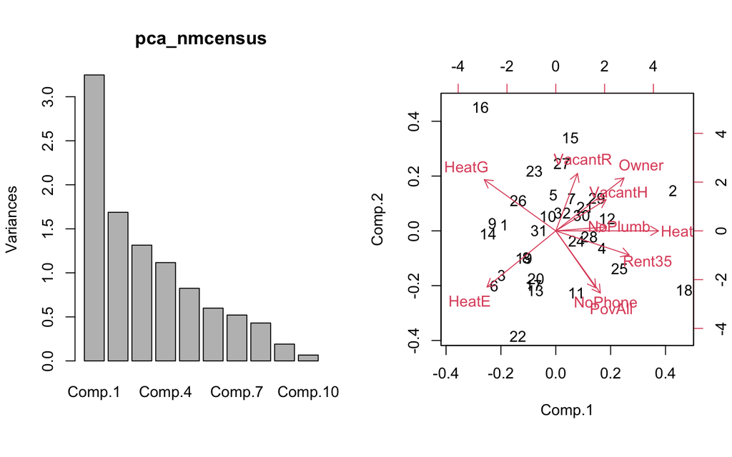

```r
par(mfrow=c(1,2))
screeplot(pca_nmcensus)
biplot(pca_nmcensus)
```

```r
par(mfrow=c(1,1))
```

## 1.4 **(1 p)** Dimension reduction

**How many** principal components would you retain to explain about 3/4ths of the total variability? How much variability is actually retained?

To answer this question, I would like you to embed R notation in the sentence you write to print the variability proportion. For example:

- Retaining 2 components explains 0.4935 of the total variability.

This is calculated by squaring the standard deviations of each component to get the variances, adding the first two variances (the indices `[1:2]`), then dividing by the sum of all the variances. That ratio give the proportion of variance for the first two components.

### 1.4.1 Solution

Retaining 4 components explains 0.7367 of the total variability.

## 1.5 **(3 p)** PC interpretations

**Interpret the number of principal components you retained** in the previous step.

*Here’s an interpretation of the first component.*

PC1 explains 32.5% of the total variation.

I’m surprised to learn that heating with wood and poverty are related, everything else makes sense. This seems to be the primary poverty component.

*Interpret the rest below.*

### 1.5.1 Solution

PC1 explains 32.5% of the total variation.

As PC1 increases, household vacancy, owner occupancy, heating with wood, lack of plumbing and phone, rent above 35%, and poverty all *increase*, **while** heating with alternate fuels decreases.

PC 1 appears to capture a rural to urban, rich to poor spectrum.

PC2 explains 16.9% of the total variation.

As PC2 increases, household vacancy, rental vacancy, owner occupancy, and heating with gas all increase, whereas electric heating lack of phone, and poverty all decrease.

PC3 explains 13.1% of the total variation.

As PC3 increases, household and rental vacancy plus electric heating increase, whereas gas heating, lack of plumbing, and rent over 35% of income all decrease.

PCs 2 and 3 seem to represent places with declining populations, perhaps? Given all the vacancies. But that doesn’t seem necessarily to correlated with poverty.

PC4 explains 11.2% of the total variation.

As PC4 increases, rent of 35% of income increases, whereas rental vacancy, gas heat, lack of plumbing and phone, and poverty all decrease.

This might represent areas with well-to-do rental communities.

## 1.6 **(3 p)** Visualizing and interpretting PCs

Here are two-dimensional plots of PC1 against PC2, PC1 against PC3, and PC2 against PC3. The points and labels are colored by poverty proportion.

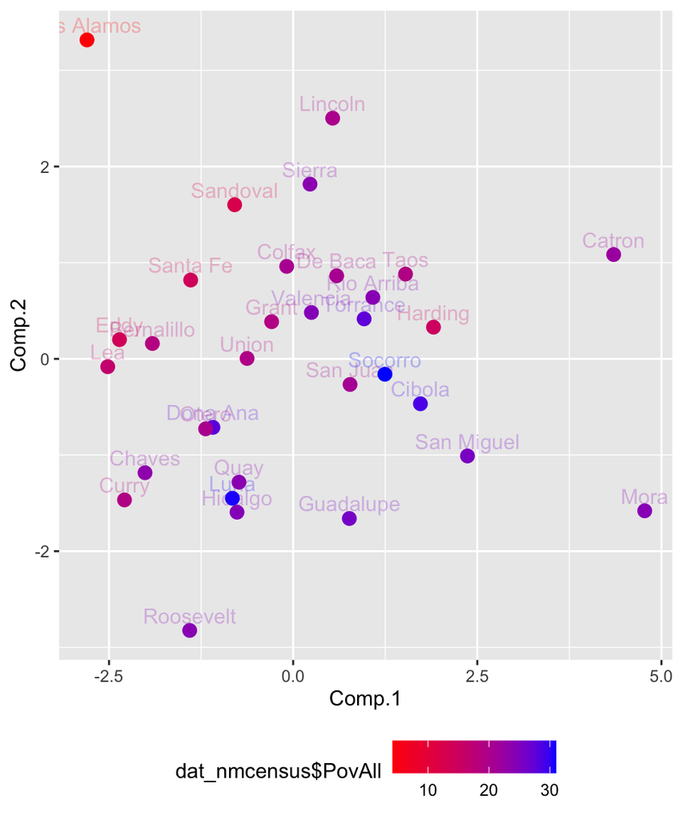

```r
library(ggplot2)
p1 <- ggplot(as.data.frame(pca_nmcensus$scores), aes(x = Comp.1, y = Comp.2, colour = dat_nmcensus$PovAll))
p1 <- p1 + scale_colour_gradientn(colours=c("red", "blue"))
p1 <- p1 + geom_text(aes(label = dat_nmcensus$County), vjust = -0.5, alpha = 0.25)
p1 <- p1 + geom_point(size = 3)
p1 <- p1 + theme(legend.position="bottom")
p2 <- ggplot(as.data.frame(pca_nmcensus$scores), aes(x = Comp.1, y = Comp.3, colour = dat_nmcensus$PovAll))
p2 <- p2 + scale_colour_gradientn(colours=c("red", "blue"))
p2 <- p2 + geom_text(aes(label = dat_nmcensus$County), vjust = -0.5, alpha = 0.25)
p2 <- p2 + geom_point(size = 3)
p2 <- p2 + theme(legend.position="none")
p3 <- ggplot(as.data.frame(pca_nmcensus$scores), aes(x = Comp.2, y = Comp.3, colour = dat_nmcensus$PovAll))
p3 <- p3 + scale_colour_gradientn(colours=c("red", "blue"))
p3 <- p3 + geom_text(aes(label = dat_nmcensus$County), vjust = -0.5, alpha = 0.25)
p3 <- p3 + geom_point(size = 3)
p3 <- p3 + theme(legend.position="none")

print(p1)
```

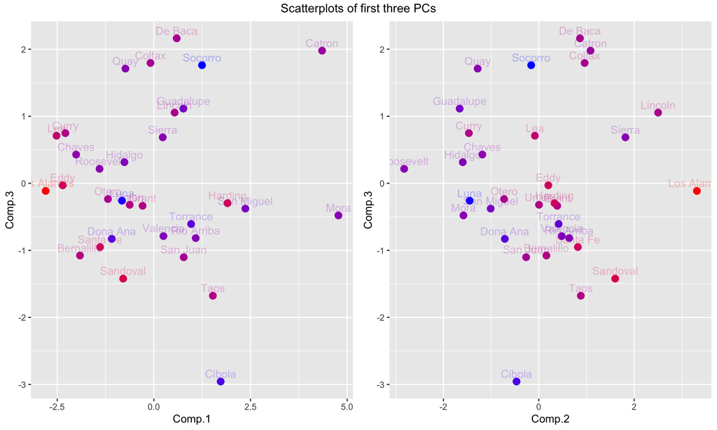

```r
library(gridExtra)
grid.arrange(grobs = list(p2, p3), nrow=1, top = "Scatterplots of first three PCs")
```

```r
#### For a rotatable 3D plot, use plot3d() from the rgl library
# ##   This uses the R version of the OpenGL (Open Graphics Library)
# library(rgl)
# plot3d(x = pca_nmcensus$scores[,"Comp.1"]
#      , y = pca_nmcensus$scores[,"Comp.2"]
#      , z = pca_nmcensus$scores[,"Comp.3"])
```

**Using your interpretations of PC1 and PC2 above**, describe these three counties: **Bernalillo, Mora, and Roosevelt**.

```r
dat_nmcensus %>% filter(County == "Los Alamos") %>% print(n = Inf, width = Inf)
```

```
# A tibble: 1 × 16
   Area County      Year VacantH VacantR Owner Renter HeatG HeatE HeatW NoPlumb
  <dbl> <chr>      <dbl>   <dbl>   <dbl> <dbl>  <dbl> <dbl> <dbl> <dbl>   <dbl>
1    28 Los Alamos  2014     0.9    14.5    75     25    88   8.3   2.5       0
  NoPhone Rent35 PovAll PovChild PovFam
    <dbl>  <dbl>  <dbl>    <dbl>  <dbl>
1     1.9   22.6    4.2      4.6    3.8
```

### 1.6.1 Solution

```r
# check after you describe it using the PCs
#dat_nmcensus %>% filter(County == "Bernalillo") %>% print(n = Inf, width = Inf)
```

```r
# check after you describe it using the PCs
#dat_nmcensus %>% filter(County == "Mora") %>% print(n = Inf, width = Inf)
```

```r
# check after you describe it using the PCs
#dat_nmcensus %>% filter(County == "Roosevelt") %>% print(n = Inf, width = Inf)
```